# Kernel PCA (KPCA)

### ■ **Overview**

> In this notebook, we will see PCA & Kernel PCA (KPCA)

### ■ **Contents**

- 1. Drawing the dataset
- 2. PCA
- 3. Kernel PCA (KPCA)

### ■ **Libraries**

```python
## numpy to handle arrays & matices
import numpy as np

## matplotlib & Seaborn to plot figures
import matplotlib.pyplot as plt
import seaborn as sns

## sklearn dependencies
from sklearn.model_selection import train_test_split
from sklearn.metrics import mean_absolute_error, mean_absolute_error
from sklearn.datasets import make_circles
from sklearn.decomposition import PCA, KernelPCA

#-----------< Setting >------------#
## set plots text font size & style
sns.set(font_scale=1.2, style='whitegrid')
plt.rcParams['figure.figsize'] = (12, 8)
```

### ■ **Kernels & Gram Matrix**

Let's start by defining different kernels that we will be using in this work:

```python
def linear_kernel(a, b):
    """linear kernel"""
    return np.inner(a, b)

def polynomial_kernel(a, b, c, d):
    """Polynomial kernel"""
    return (np.inner(a, b) + c) ** d

def gaussian_kernel(a, b, gamma):
    """Gaussian kernel"""
    return np.exp(-.5 * np.linalg.norm((a - b)**2) / gamma)

def laplace_kernel(a, b):
    """Laplce kernel"""
    return np.exp(-np.linalg.norm(a - b, ord=1))

def exponential_kernel(a, b):
    """Exponential kernel"""
    return np.exp(np.inner(a, b))

def gram_matrix(X, kernel, gamma=None):
    """returns Gram matrix of X using the given kernel"""
    n, _ = X.shape
    K = np.array([kernel(X[i], X[j], gamma=gamma)
                  for i in range(n)
                  for j in range(n)]).reshape(n, n)
    return K
```

### ■ **1. Dataset** (↑)

#### **1.1. Generate data**

Let's generate training & validation datasets.

```python
## random seed for repreducibility
random_seed = 1
np.random.seed(random_seed)

## Number of training & validation samlples
n_samples = 1_000
n_val = 2_000

## random samples parameters
noise = .05
factor = .3

## generate training & validation samples
X, y = make_circles(n_samples=n_samples, factor=factor, noise=noise)
X_val, y_val = make_circles(n_samples=n_val, factor=factor, noise=noise)
```

#### **1.2. Display data**

Here is a picture of the generated data.

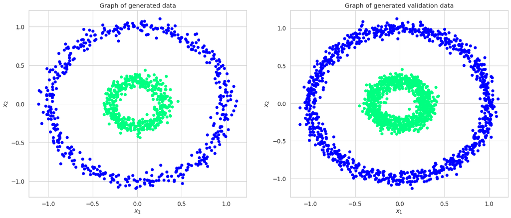

```python
## display data
fig, (ax1, ax2) = plt.subplots(nrows=1, ncols=2, figsize=(20, 8))

ax1.scatter(X[:, 0], X[:, 1], c=y, cmap='winter')
ax1.set_xlabel(r'$x_1$')
ax1.set_ylabel(r'$x_2$')
ax1.set_title('Graph of generated data')

ax2.scatter(X_val[:, 0], X_val[:, 1], c=y_val, cmap='winter')
ax2.set_xlabel(r'$x_1$')
ax2.set_ylabel(r'$x_2$')
ax2.set_title('Graph of generated validation data')

plt.show()
```

### ■ **2. PCA** (↑)

In this section, we will apply & evaluate PCA model on the data generated earlier.

#### **2.1. PCA on generated data**

Let's apply a PCA model on our generated dataset.

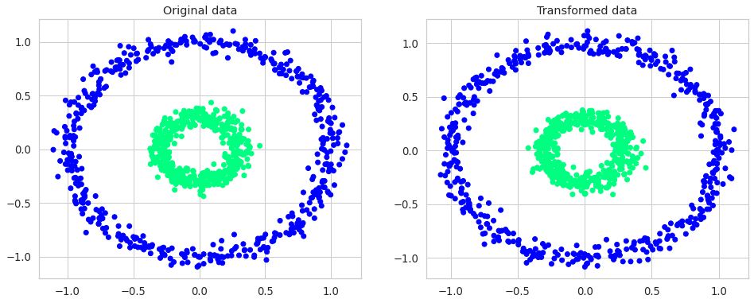

```python
## pca on data
pca = PCA(n_components=2)
X_pca = pca.fit_transform(X)

## display
fig, (ax1, ax2) = plt.subplots(nrows=1, ncols=2, figsize=(16, 6))
ax1.scatter(X[:, 0], X[:, 1], c=y, cmap='winter')
ax2.scatter(X_pca[:, 0], X_pca[:, 1], c=y, cmap='winter')
ax1.set_title('Original data')
ax2.set_title('Transformed data')
plt.show()
```

```python
## ratio of explained variance
pca.explained_variance_ratio_
```

```
array([0.50212282, 0.49787718])
```

**Comments:**

- The ratio of explained variance is the same in both directions.
- The new features given by PCA are mostly the same as the original ones.
- PCA does not seem to work well in this case :(.

#### **2.2. Spectrum**

```python
## covariance matrix of X
cov_mat = X.T.dot(X) / n_samples

## eigenvalues of covariance matrix
eigv, _ = np.linalg.eig(cov_mat)
eigv
```

```
array([0.27446505, 0.27680542])
```

**Comment:** The two eigenvalues are mostly the same, which explaines in some sense the results above !

### ■ **3. Kernel PCA** (↑)

In this last section, we will apply Kernel PCA to our dataset, by using both Polynomial & Gaussian kernels.

#### **3.1. Polynomial Kernel**

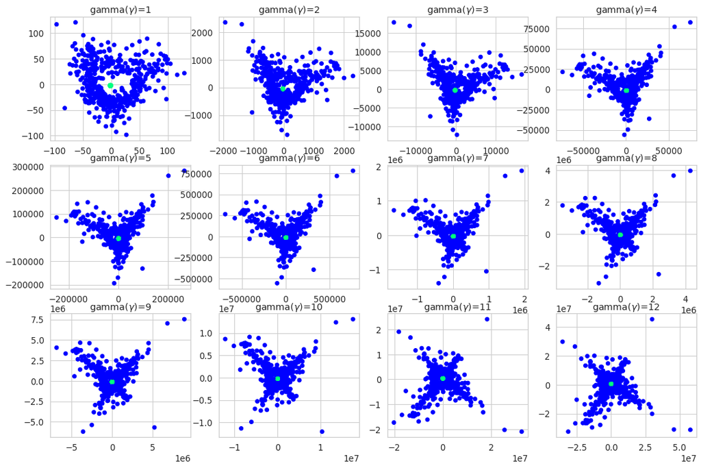

```python
## create & fit KPCA
gamma = 5
degree = 13
kernel = 'poly'
KPCA = KernelPCA(n_components=2, gamma=gamma, degree=degree, kernel=kernel)
X_kpca = KPCA.fit_transform(X)


## display transformed data
fig, axes = plt.subplots(nrows=3, ncols=4, figsize=(18, 12))
axes = axes.flatten()

gammas = range(1, 13)
for e, gamma in enumerate(gammas):
    KPCA = KernelPCA(n_components=2, gamma=gamma, degree=degree, kernel=kernel)
    X_kpca = KPCA.fit_transform(X)
    axes[e].scatter(X_kpca[:, 0], X_kpca[:, 1], c=y, cmap='winter')
    axes[e].set_title(r'gamma($\gamma$)=' + str(gamma))

plt.show()
```

**Comment:** polynomial kernel does not seem to be suited for such cases, even with higher polynomial degrees.

#### **3.2. Gaussian Kernel**

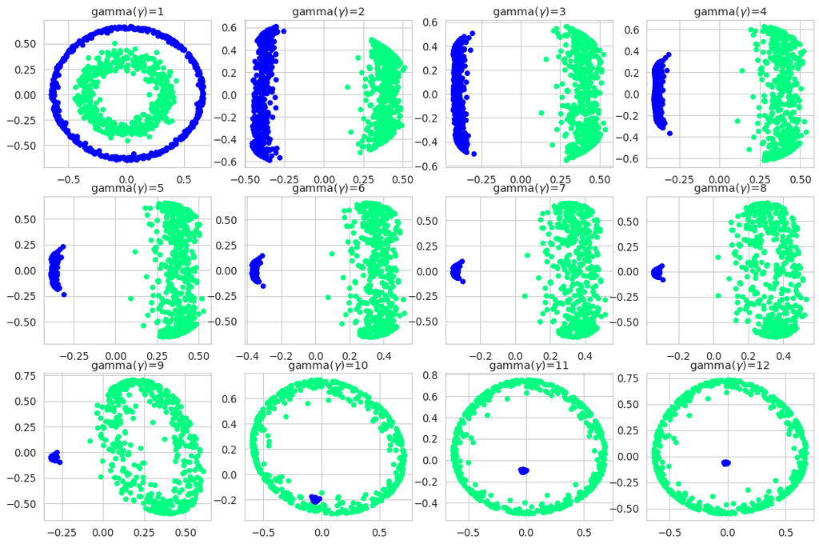

```python
## create & fit KPCA
gamma = 10
kernel = 'rbf'
KPCA = KernelPCA(n_components=2, gamma=gamma, kernel=kernel)
X_kpca = KPCA.fit_transform(X)


## display transformed data
fig, axes = plt.subplots(nrows=3, ncols=4, figsize=(18, 12))
axes = axes.flatten()

gammas = range(1, 13)
for e, gamma in enumerate(gammas):
    KPCA = KernelPCA(n_components=2, gamma=gamma, kernel='rbf')
    X_kpca = KPCA.fit_transform(X)
    axes[e].scatter(X_kpca[:, 0], X_kpca[:, 1], c=y, cmap='winter')
    axes[e].set_title(r'gamma($\gamma$)=' + str(gamma))

plt.show()
```

**Comments:**

- Unlike polynomial kernel, the Gaussian one seem to work well.
- There is a range of values of bindwidth that makes things work perfectly, but beyond a given value (in our case $\gamma=9$) it fails to linearly separate the two classes.

### **3.3. spectrum**

- $\hat{\Sigma}=\dfrac1n\sum_{i}k_{x_i}\otimes k_{x_i}=\dfrac1n\sum_{i}X_iX_i^T=\frac{X^TX}{n}$
- $K_n = \frac{XX^T}{n} = \left\{\frac{X_i^TX_j}{n}\right\}_{i, j}$
- The non-zero eignevalues of $\hat{\Sigma}$ are exactly the same as the gram matrix: $$Sp(K_n) = Sp(\hat{\Sigma})$$

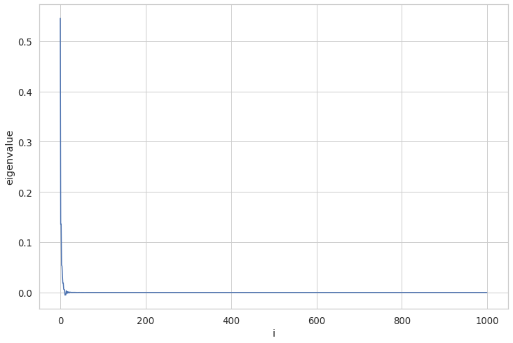

```python
## compute gram matrix with gaissian kernel
gamma = .5
kenrel = gaussian_kernel
K = gram_matrix(X, kenrel, gamma=gamma)

## the normalized Gram matrix
Kn = K / n_samples

## compute the eigenvalues of the gram matrix
eigv, _ = np.linalg.eig(Kn)

## display eigenvalues
plt.plot(eigv)
plt.xlabel('i')
plt.ylabel('eigenvalue')
plt.show()
```

```python
## the number of eigen values
n_eigv = len(eigv)

print(f'number of eigenvalues: {n_eigv}')

## compute the non-zero eigenvalues
non_zero_eigv = np.sum(eigv > 10e-5)

print(f'number of non-zero eigenvalues: {non_zero_eigv}')
```

```
number of eigenvalues: 1000
number of non-zero eigenvalues: 28
```

**Comment:** $$\normalsize\gamma \uparrow \leadsto \|u\|_o \downarrow \text{ sparsity}$$

Copyright © 2021 Omar Ikne